# A Quick Introduction to iNEXT.link via Examples

CHUNG-E LO

2021-03-30

There are Four main functions in `iNEXT.link`, including `iNEXT_ND`, `AsyND`, `ObsND` and `estimateND`.

1. `iNEXT_ND`: provides a seamless rarefaction and extrapolation sampling curve for Chao et al.’s Network diversity. See Chao et al. (2010, 2015) and Hsieh and Chao (2017) for pertinent background and methods. It is the network extension of `iNEXT` function in `iNEXT` package.
2. `AsyND`: computes asymptotic network diversity estimates with respect to specified/default diversity order q to infer network diversity (ND) and phylogenetic network diversity (PND).
3. `ObsND`: computes empirical (i.e., observed) phylogenetic diversity (PD) and phylogenetic Hill numbers (meanPD, mean phylogenetic diversity) for specified/default order q and reference time; see Chao et al. (2010) for details of PD and meanPD
4. `estimateND`: computes Chao et al.’s (2010) phylogenetic diversity (PD, effective total branch lengths, for diversity order q = 0, 1 and 2) and mean phylogenetic diversity (meanPD, phylogenetic Hill numbers or the effective number of lineages, q = 0, 1 and 2) for given values of sample coverage. See Chao et al. (2010, 2015) and Hsieh and Chao (2017) for formulas and interpretations. It is the phylogenetic extension of `estimateD` in `iNEXT` package.

## **SOFTWARE NEEDED TO RUN iNEXT.link IN R:**

- Required: [R](https://cran.r-project.org/)
- Suggested: [RStudio IDE](https://www.rstudio.com/products/RStudio/#Desktop)

## **HOW TO RUN iNEXT.link:**

The `iNEXT.link` package is available on [CRAN](https://cran.r-project.org/package=PhD) and can be downloaded with a standard R installation procedure using the following commands. Before installation, the additional visualization and computation extension packages (`chaoUtility`,`ape`, `dplyr`, `ggplot2`, `phyclust`, `Rcpp`) must be loaded. Please note that currently, package `chaoUtility` can only be available via github instead of CRAN and thus the installation procedure slightly differs from the one of standard R installation.

```r
## install chaoUtility package from github
install.packages("devtools")
library(devtools)
install_github("chaolab2019/chaoUtility")

## install iNEXT.links package from CRAN
install.packages("iNEXT.link")
## Or instead, install the latest version from github
install_github("AnneChao/iNEXT.link")

## import packages
library(chaoUtility)
library(phytools)
library(iNEXT)
# library(iNEXT.link)
```

## **DATA FORMAT/INFORMATION**

In iNEXT.link package, all four main functions share the same required format of `data`. Now, only abundance data is supported.

```r
# include abundance data
# data(data.abu)
```

## **MAIN FUNCTIONS:**

We describe the four main functions with default arguments below :

#### a. Taxonomic

1. **iNEXT_ND()**:

```r
iNEXT_ND(Norfolk, datatype = "abundance", q = c(0,1,2),
         endpoint = NULL, knots = 40, size = NULL, nboot = 30, conf = 0.95)
```

The arguments of this function are described below.

[output not shown]

The sequence of sample sizes for which PD/meanPD R/E curve will be estimated is determined by `endpoint`, `knots` and `size`. If `size` is specified by users, then PD/meanPD will be estimated for these sizes plus the reference sample size(total species abundances for abundance data; total sampling units for incidence data). If `knots=K`, then the sequece would be K/2 evenly‐spaced knots (sample sizes) before reference sample size and K/2 from reference sample size to `endpoint`, where the `endpoint` is default to double reference sample size. By default, `knots=40`. If `endpoint` specified by users is smaller than the reference sample size, `iNEXTPD` only computes rarefaction estimates for approximately `knots` evenly spaced knots before the `endpoint`.

2. **AsyND()**:

```r
asy = AsyND(Norfolk, q = c(0,1,2), datatype = "abundance", nboot = 30)
```

The arguments of this function are described below.

[output not shown]

3. **ObsND()**:

```r
obs = ObsND(Norfolk, q = c(0,1,2), datatype = "abundance", nboot = 30)
```

The arguments of this function are described below.

[output not shown]

4. **estimatePD()**:

```r
estimateND(Norfolk, datatype="abundance", base="coverage",level=0.7, nboot = 30,conf=0.95)
```

The arguments of this function are described below.

[output not shown]

#### b. Phylogenetic

1. **iNEXT_PND()**:

```r
iNEXT_PND(x = puerto.rico$data, row.tree = puerto.rico$row.tree, col.tree = puerto.rico$col.tree, q = c(0,1,2),
          datatype = "abundance", endpoint = NULL, knots = 40,
          size = NULL, conf = 0.95, nboot = 10)
```

The arguments of this function are described below.

[output not shown]

The sequence of sample sizes for which PD/meanPD R/E curve will be estimated is determined by `endpoint`, `knots` and `size`. If `size` is specified by users, then PD/meanPD will be estimated for these sizes plus the reference sample size(total species abundances for abundance data; total sampling units for incidence data). If `knots=K`, then the sequece would be K/2 evenly‐spaced knots (sample sizes) before reference sample size and K/2 from reference sample size to `endpoint`, where the `endpoint` is default to double reference sample size. By default, `knots=40`. If `endpoint` specified by users is smaller than the reference sample size, `iNEXTPD` only computes rarefaction estimates for approximately `knots` evenly spaced knots before the `endpoint`.

2. **AsyND()**:

```r
# AsyPND(puerto.rico$data, q = c(0,1,2), datatype = "abundance", nboot = 30)
```

The arguments of this function are described below.

[output not shown]

3. **PhdObs()**:

```r
# AsyPND(data.abu, datatype = "abundance", tree, q = c(0,1,2), datatype = "abundance", nboot = 30)
```

The arguments of this function are described below.

[output not shown]

4. **estimatePD()**:

```r
estimatePND <- function(data, datatype = "abundance", tree, q = c(0,1,2), reftime=NULL,
                        level = NULL, nboot = 50, conf = 0.95)
```

The arguments of this function are described below.

[output not shown]

## **iNEXT.link VIA EXAMPLES: Network diversity Analysis**

We now apply four main functions to the abundance data to see the outputs:

### Main function:

### 1.`iNEXT_ND()`:

```r
sample1 <- iNEXT_ND(x = Norfolk, datatype = "abundance", nboot = 10)
```

`iNEXT_ND()` returns a list containing three objects:

```r
kable(sample1$DataInfo)
```

| Assemblages | n | S.obs | Links.obs | S.obs.row | S.obs.col | Connectance | Coverage | f1 | f2 | f3 | f4 | f5 | f6 | f7 | f8 | f9 | f10 |
| --- | --- | --- | --- | --- | --- | --- | --- | --- | --- | --- | --- | --- | --- | --- | --- | --- | --- |
| Shelfanger | 980 | 52 | 85 | 16 | 36 | 0.1476 | 0.9674 | 32 | 17 | 6 | 6 | 4 | 2 | 1 | 5 | 1 | 1 |
| Hickling | 3150 | 78 | 146 | 17 | 61 | 0.1408 | 0.9810 | 60 | 17 | 10 | 7 | 9 | 3 | 6 | 3 | 2 | 1 |

- `$iNextEst`: Size-based / coverage-based diversity estimates along with confidence intervals and related statistics.

#### size-based

```r
kable(head(sample1$iNextEst$size_based,5))
```

| Assemblage | m | Method | Order.q | qD | qD.LCL | qD.UCL | SC | SC.LCL | SC.UCL |
| --- | --- | --- | --- | --- | --- | --- | --- | --- | --- |
| Shelfanger | 1 | Rarefaction | 0 | 1.00000 | 1.00000 | 1.00000 | 0.2477455 | 0.2232437 | 0.2722474 |
| Shelfanger | 55 | Rarefaction | 0 | 18.16282 | 17.43447 | 18.89118 | 0.7823029 | 0.7666953 | 0.7979105 |
| Shelfanger | 109 | Rarefaction | 0 | 28.09434 | 26.62396 | 29.56472 | 0.8424680 | 0.8273176 | 0.8576184 |
| Shelfanger | 164 | Rarefaction | 0 | 35.84378 | 33.62454 | 38.06302 | 0.8736846 | 0.8597099 | 0.8876594 |
| Shelfanger | 218 | Rarefaction | 0 | 42.10131 | 39.20173 | 45.00090 | 0.8937377 | 0.8810065 | 0.9064689 |

#### coverage-based

```r
kable(head(sample1$iNextEst$coverage_based,5))
```

| Assemblage | goalSC | SC | m | Method | Order.q | qD | qD.LCL | qD.UCL |
| --- | --- | --- | --- | --- | --- | --- | --- | --- |
| Shelfanger | 0.2477455 | 0.2477471 | 1.000009 | Rarefaction | 0 | 1.000007 | 0.9315419 | 1.068472 |
| Shelfanger | 0.7823029 | 0.7823029 | 55.000000 | Rarefaction | 0 | 18.162822 | 15.7548170 | 20.570826 |
| Shelfanger | 0.8424680 | 0.8424680 | 108.999992 | Rarefaction | 0 | 28.094337 | 23.9682685 | 32.220405 |
| Shelfanger | 0.8736846 | 0.8736846 | 163.999994 | Rarefaction | 0 | 35.843780 | 30.3526376 | 41.334922 |
| Shelfanger | 0.8937377 | 0.8937377 | 217.999997 | Rarefaction | 0 | 42.101315 | 35.5824602 | 48.620169 |

- `$AsyEst`: Asymptotic/ Empirical diversity estimates along with confidence intervals and related statistics.

```r
kable(head(sample1$AsyEst,9))
```

[output not shown]

### 2. ggiNEXT_ND

To visualize the curves, use `ggiNEXT_ND` to obtain plots based on `ggplot2` package. This function provides three types of curves, which can be specified in the argument `plot.type`:

1. Sample-size-based rarefaction and extrapolation curve (`plot.type = 1`): sampling curve depicting phylogenetic diversity estimates as a function of sample size.
2. Sample completeness curve (`plot.type = 2`): the curve of sample coverage as a function of sample size.
3. Coverage-based R/E curve (`plot.type = 3`): sampling curve depicting Network diversity estimates as a function of sample coverage.

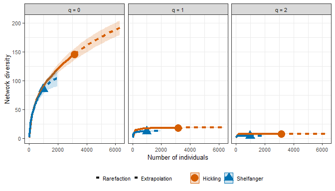

```r
ggiNEXT_ND(sample1, type = 1,facet = "Order.q" )
```

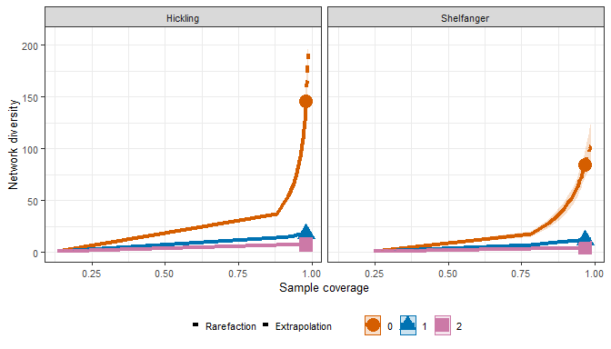

```r
ggiNEXT_ND(sample1, type = 3, facet = "Assemblage")
```